# ANOVA

Working on k sample problems where the sample sizes are same.

### *H0 = mu1 = mu2 = muk*

### *H1 = H0 is not true*

Assumptions

1. Assume Independence
2. Assume/Check Normal Population using QQPLOT
3. Assume/Check equal variances or Homoscedacity

We set a seed value so that the random numbers generated are the same

```r
set.seed(12345)
```

Now we generate the random numbers and see if we are getting the numbers with same mean and variance. We also test with a different mean and see how the box plots look in both the cases

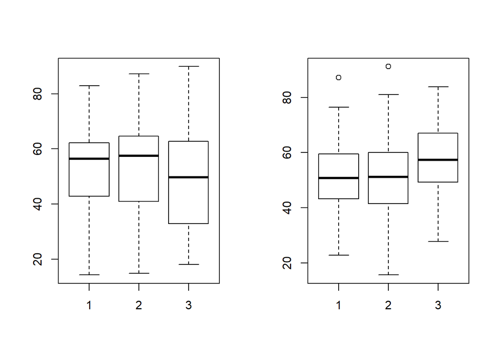

```r
par(mfrow=c(1,2))
X1 = rnorm(50,mean=50, sd=15)
X2 = rnorm(50,mean=50, sd=15)
X3 = rnorm(50,mean=50, sd=15)
boxplot(X1,X2,X3)
Y1 = rnorm(50,mean=50, sd=15)
Y2 = rnorm(50,mean=50, sd=15)
Y3 = rnorm(50,mean=60, sd=15)
boxplot(Y1,Y2,Y3)
```

We check the variances and we take the average of the 3 variances also called the “Within sample”.

```r
var(X1)
```

```
## [1] 270.5627
```

```r
var(X2)
```

```
## [1] 292.3465
```

```r
var(X3)
```

```
## [1] 284.8077
```

```r
within_ms=(var(X1)+var(X2)+var(X3))/3
within_ms
```

```
## [1] 282.5723
```

```r
between_ms=var(c(mean(X1),mean(X2),mean(X3)))*50
var(c(mean(Y1),mean(Y2),mean(Y3)))*50
```

```
## [1] 726.8044
```

```r
between_ms
```

```
## [1] 298.4645
```

```r
F = between_ms/within_ms
F
```

```
## [1] 1.056241
```

```r
p = 1 - pf(F,df1 = 2, df2 = 147)
p
```

```
## [1] 0.3503847
```

Next we see how all the above calulcations can be acheived using one command - *Anova* in R

```r
x.all = c(X1,X2,X3)
group = factor(c(rep(1,50),rep(2,50),rep(3,50)))
head(x.all)
```

```
## [1] 58.78293 60.64199 48.36045 43.19754 59.08831 22.73066
```

```r
head(group)
```

```
## [1] 1 1 1 1 1 1
## Levels: 1 2 3
```

```r
anova(lm(x.all ~ group))
```

```
## Analysis of Variance Table
##
## Response: x.all
##            Df Sum Sq Mean Sq F value Pr(>F)
## group       2    597  298.46  1.0562 0.3504
## Residuals 147  41538  282.57
```